# NTOLab12

Ethan, Anderson, David, Ryan, Arie

4/12/2019

#### Overall Questions

- Question(Two-Sample Permutation test): From 1957-2007, how does the mean difference of GDP change over time between the United States and China, India, Japan, South Korea, and Indonesia? This question is important and interesting because over time it will show if the GDP per capita of the asain countries catch up to the GDP per capita of the United States, as well as how GDP was impacted by events in history.
- Question(Correlation Permutation test): Is there a correlation bewteen GDP per capita and life expectancy? This question is important because it will give us a better understanding of which countries struggle to get better access to health care, education etc. This question is also interesting because it can help policy makers decide what action to take to advance the country they represent.

#### Two-Sample Permuatation test function

```r
perm_mean <- function(perms, values, n1)
{
## step one
  result <- vector("numeric", perms)

  # Loop throught number of permutations
  for (i in 1:perms)
  {
    x <- sample(1:length(values), n1)

  group1 <- values[x]
  group2 <- values[-x]

  diff <- mean(group1)-mean(group2)
  result[i] <- diff
    # Step 4:

  }
  # Step 5:
 result <- as.tibble(result)
 #print(result)
  }

#test1 <- perm_mean(1000,c(1:100),50)

#ggplot(data = test1, mapping = aes(x= value))+
 # geom_density()
```

#### Correlation Permutation test function

```r
perm_cor <- function(perms,x,y){
  result <- vector("numeric",perms)

for( i in c(1:perms))
{
  y <- sample(y,length(y))
  c <- cor(x,y)
  result[i] <- c
}
result <- as.tibble(result)
#print(result)
}
#perm_cor(100,c(1:10),c(1:10))
```

#### Pre-Permutation Analysis

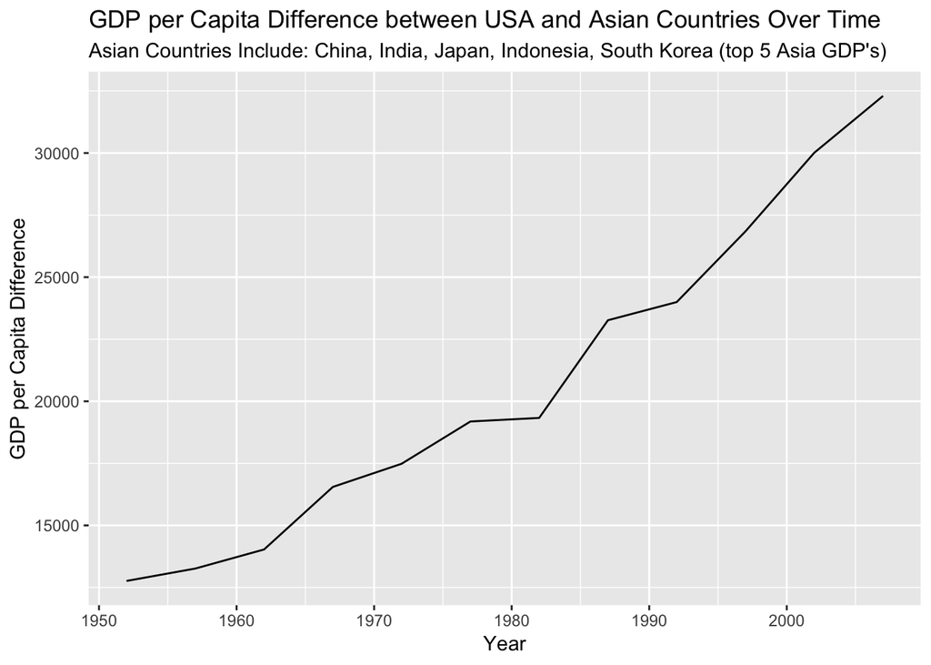

- Explanation: This graph relates to our first question “Is there a statistically significant difference in the means between GDP per capita of the US and average GDP per capita of the 5 largest Asian economies?”. We first calculated the average GDP per capita of China, India, Japan, South Korea, and Indonesia for each year in 5 year intervals as one column, the GDP per capita of the US for each of these years as another column, and the difference between these values as the third column. Finally, we plotted this difference over the timespan (1952-2007) and found that it has increased at a pretty consistent rate.

[figure not shown]

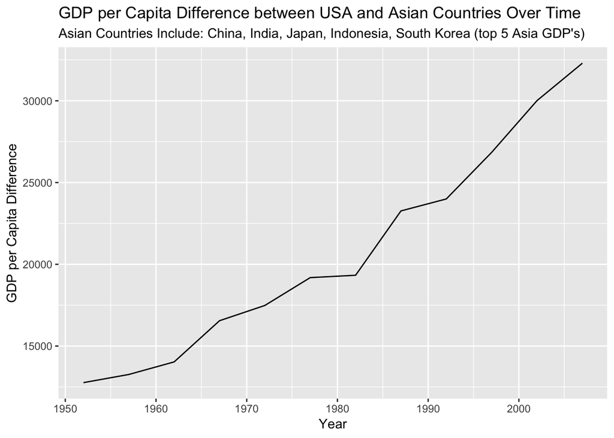

- Explanation: This graph relates to our first question “Is there a statistically significant difference in the means between GDP per capita of the US and average GDP per capita of the 5 largest Asian economies?”. We first calculated the average GDP per capita of China, India, Japan, South Korea, and Indonesia for each year in 5 year intervals as one column, the GDP per capita of the US for each of these years as another column, and the difference between these values as the third column. Finally, we plotted this difference over the timespan (1952-2007) and found that it has increased at a pretty consistent rate.

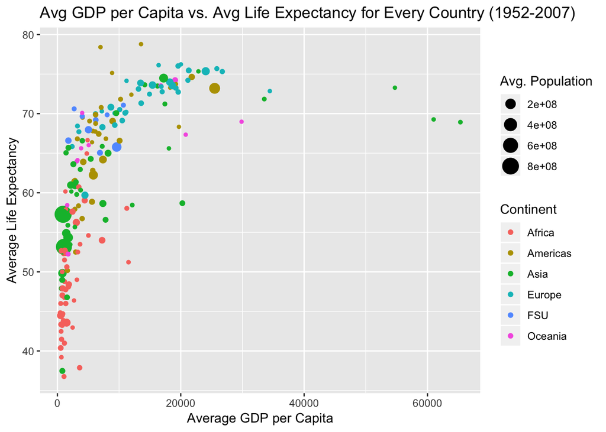

- Explanation: This graph relates to our second question “Is there a correlation bewteen GDP per capita and life expectancy?” We plotted average GDP per capita on the x-axis against average life expectancy on the y-axis throughout the timeframe of 1952-2007, where each point iteslf represents each country, the color of the point represents the continent, and the size of the point represents the average population of the country. From this graph we found that there was a correlation of .6 between GDP per capita and life expectancy, implying a strong positive correlation. This makes sense because richer countries have better access to health care.

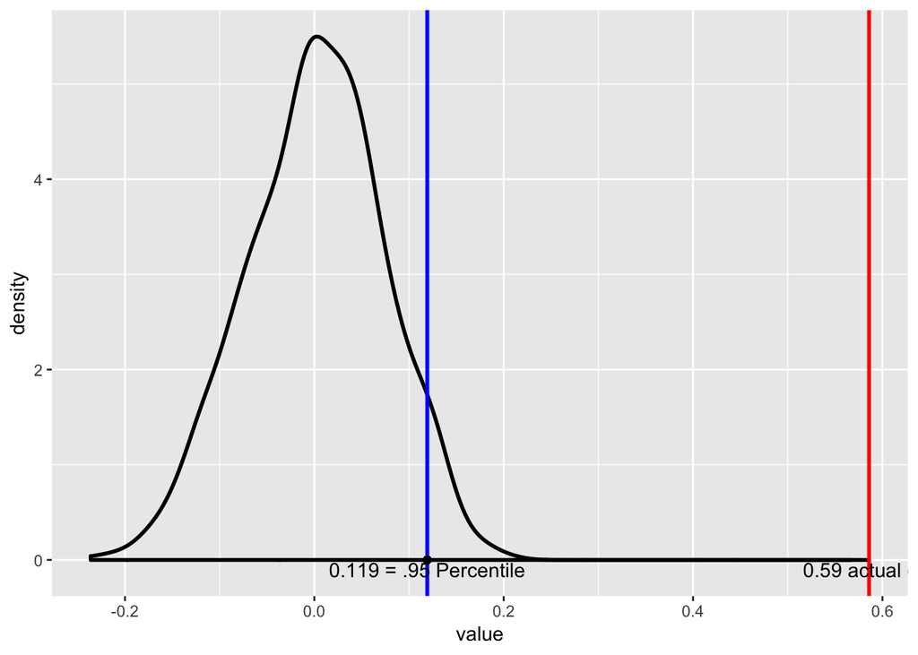

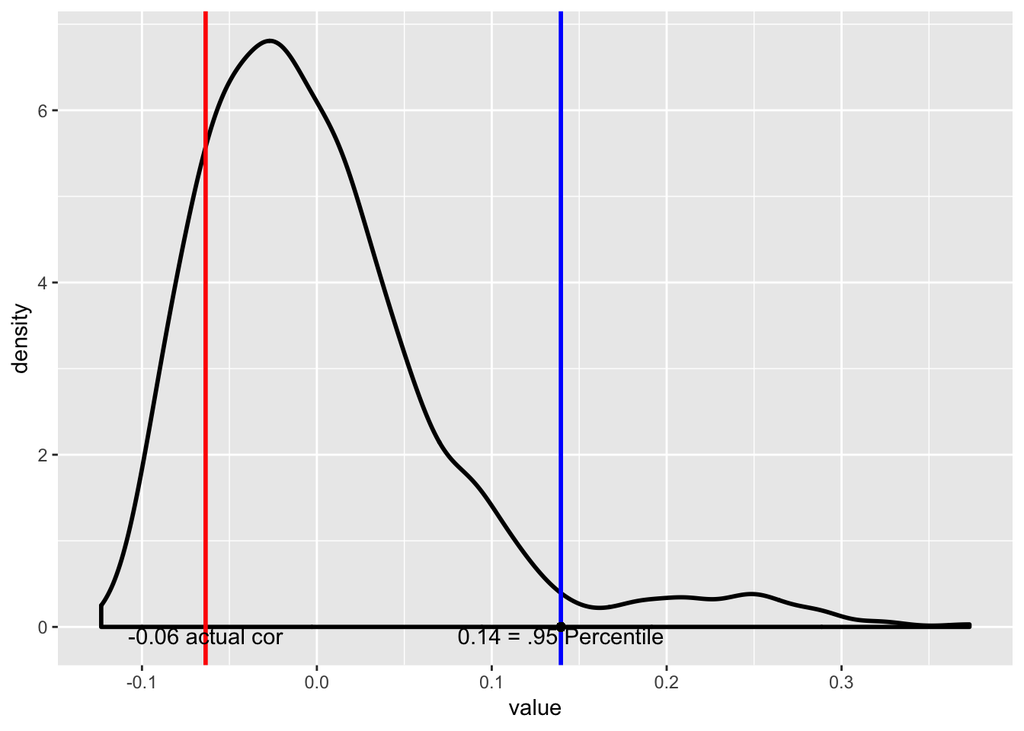

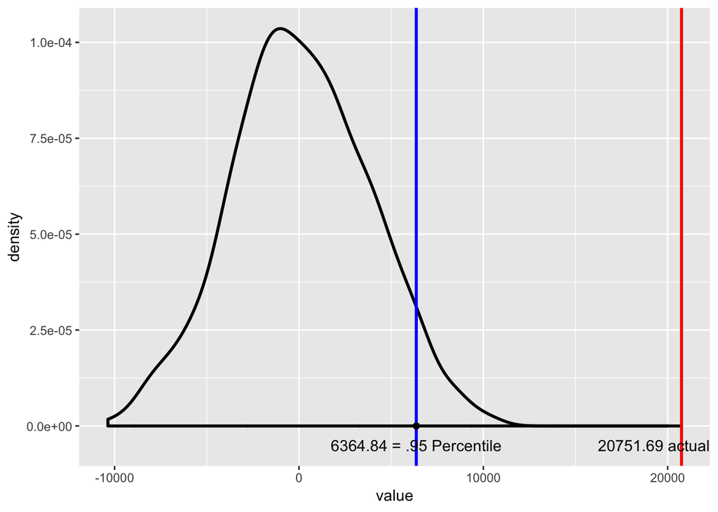

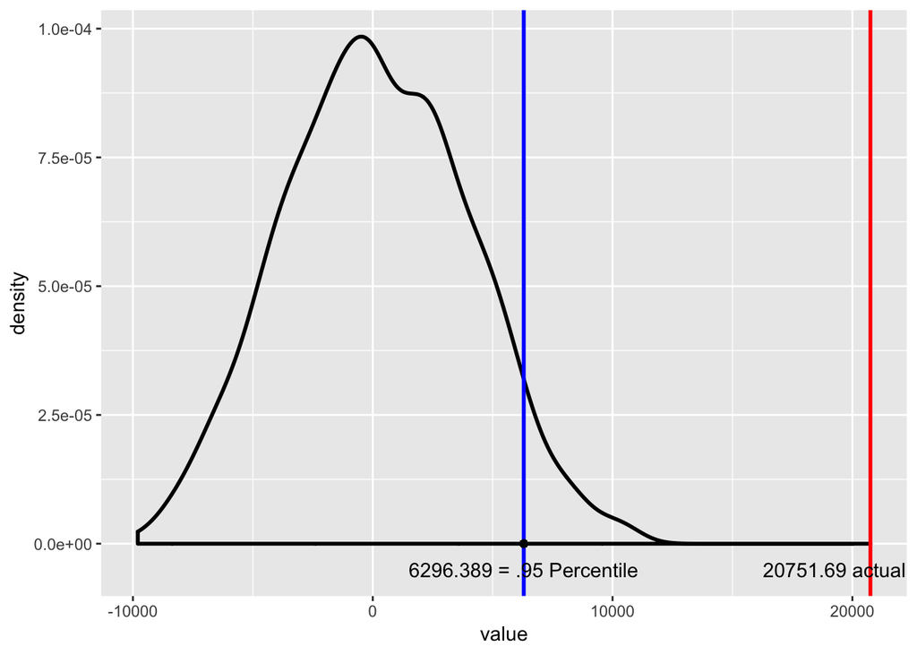

#### Conclusion

- Conclusion (Correlation Permutation Test) : There is a positive correlation between life expectancy and GDP per capita. The plot coneys the average GDP and life expectancy correlation for all countries. The blue line in the plot shows the ninety-fifth percentile which is all of our significant data. The red line showing our actual correlation is to the right of the red line meaning that the actual correlation and data between GDP per capita and life expectancy is meaningful and positive.

Conclusion (Two-Sample Permutation Test): The mean difference between the USA and countries in Asia is shown to be significant. We decided to plot the mean of the difference in the average GDP of the USA subtracted against the average GDP in various countries of Asia. The blue line in the plot shows at what value the data becomes significant, and the red line to the right of the blue is our actual data which has a value higher than the significant number the graph gives us. In conclusion since the actual data fits the ninety-fifth percentile it becomes significant.

#### Who did what

- David: Wrote Permutation Mean Test Function and helped Ryan with the Permutaion Corrleation Test Function. Helped Anderson with the graphing the distribution of perm mean and per cor for our questions. Added vertical lines to graphs to show percentile Vs. actual. Did some overall edits.
- Ethan: Made the whole pre-permutation analysis section
- Ryan: Helped finalize second function

- Anderson: Helped finalize first function, wrote conclusions

- Arie: Helped with formatting and explanations, wrote questions

# NTOLab12

Ethan, Anderson, David, Ryan, Arie

4/12/2019

#### Overall Questions

- Question(Two-Sample Permutation test): From 1957-2007, how does the mean difference of GDP change over time between the United States and China, India, Japan, South Korea, and Indonesia? This question is important and interesting because over time it will show if the GDP per capita of the asain countries catch up to the GDP per capita of the United States, as well as how GDP was impacted by events in history.
- Question(Correlation Permutation test): Is there a correlation bewteen GDP per capita and life expectancy? This question is important because it will give us a better understanding of which countries struggle to get better access to health care, education etc. This question is also interesting because it can help policy makers decide what action to take to advance the country they represent.

#### Two-Sample Permuatation test function

```r
perm_mean <- function(perms, values, n1)
{
## step one
  result <- vector("numeric", perms)

  # Loop throught number of permutations
  for (i in 1:perms)
  {
    x <- sample(1:length(values), n1)

  group1 <- values[x]
  group2 <- values[-x]

  diff <- mean(group1)-mean(group2)
  result[i] <- diff
    # Step 4:

  }
  # Step 5:
 result <- as.tibble(result)
 #print(result)
  }

#test1 <- perm_mean(1000,c(1:100),50)

#ggplot(data = test1, mapping = aes(x= value))+
 # geom_density()
```

#### Correlation Permutation test function

```r
perm_cor <- function(perms,x,y){
  result <- vector("numeric",perms)

for( i in c(1:perms))
{
  y <- sample(y,length(y))
  c <- cor(x,y)
  result[i] <- c
}
result <- as.tibble(result)
#print(result)
}
#perm_cor(100,c(1:10),c(1:10))
```

#### Pre-Permutation Analysis

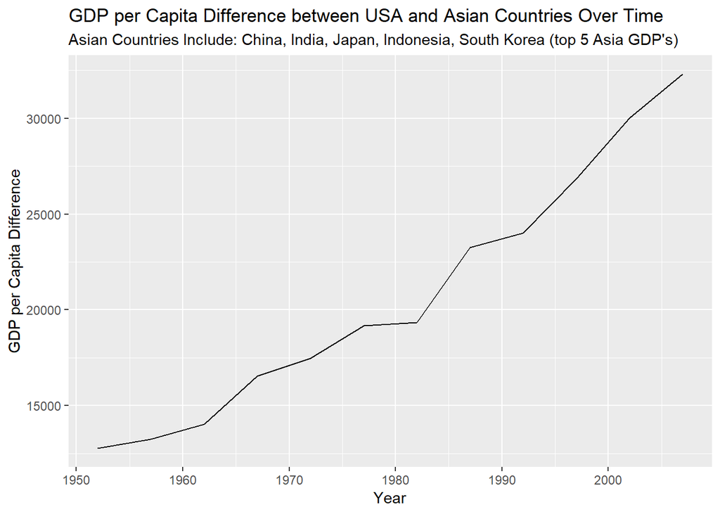

- Explanation: This graph relates to our first question “Is there a statistically significant difference in the means between GDP per capita of the US and average GDP per capita of the 5 largest Asian economies?”. We first calculated the average GDP per capita of China, India, Japan, South Korea, and Indonesia for each year in 5 year intervals as one column, the GDP per capita of the US for each of these years as another column, and the difference between these values as the third column. Finally, we plotted this difference over the timespan (1952-2007) and found that it has increased at a pretty consistent rate.

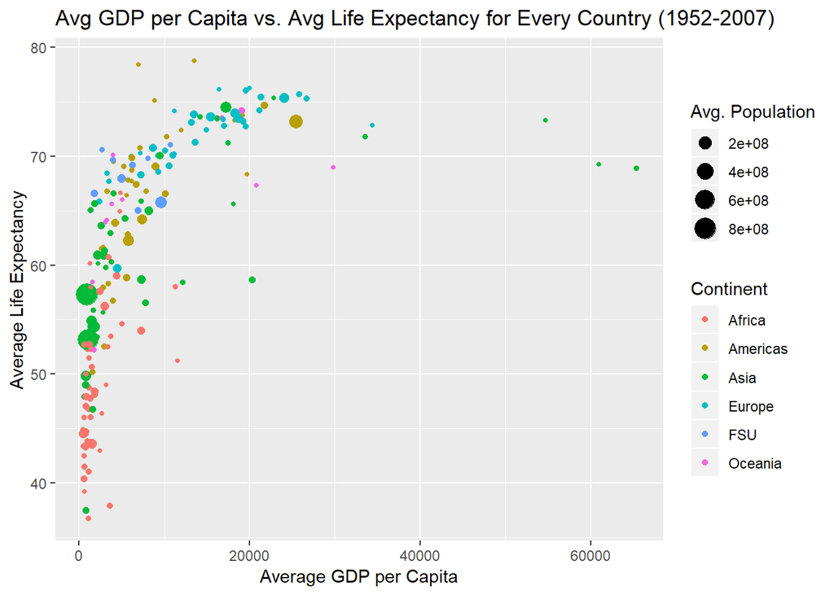

- Explanation: This graph relates to our second question “Is there a correlation bewteen GDP per capita and life expectancy?” We plotted average GDP per capita on the x-axis against average life expectancy on the y-axis throughout the timeframe of 1952-2007, where each point iteslf represents each country, the color of the point represents the continent, and the size of the point represents the average population of the country. From this graph we found that there was a correlation of .6 between GDP per capita and life expectancy, implying a strong positive correlation. This makes sense because richer countries have better access to health care.

#### Permutation Correlation Test

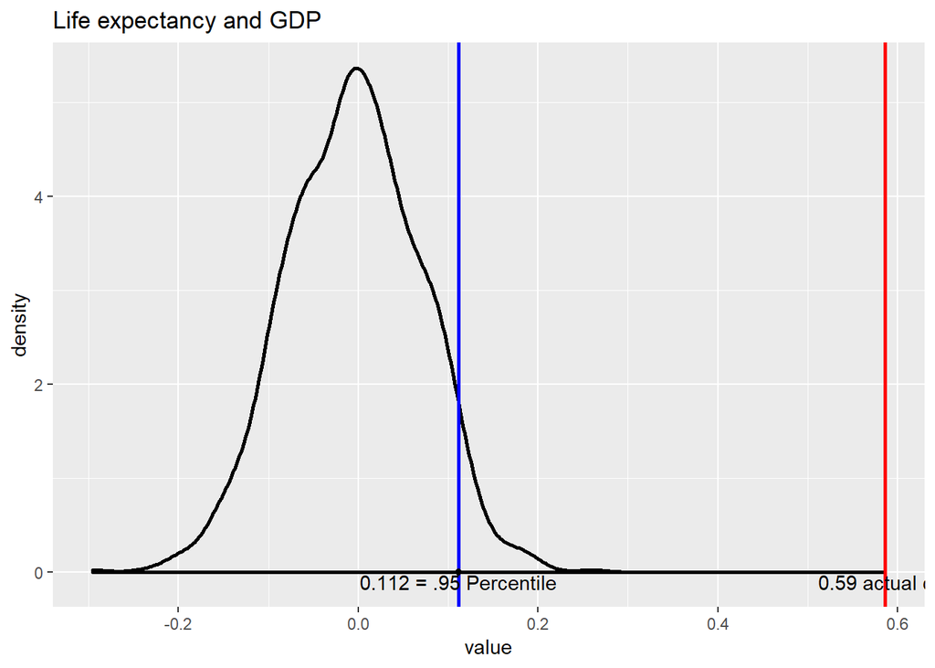

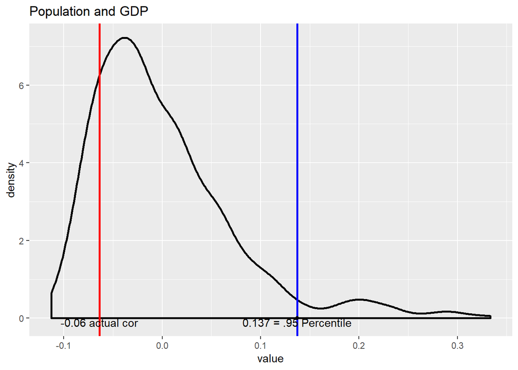

#### Permutation Mean Test

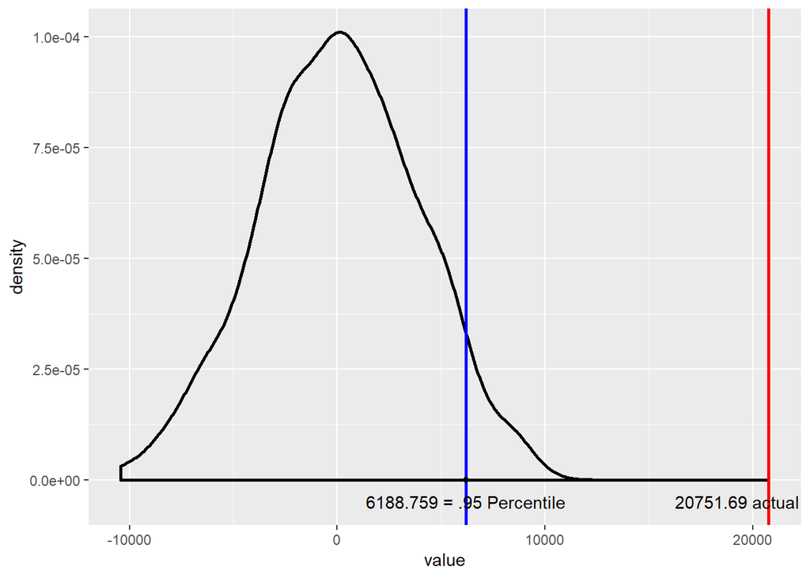